# DAS Project 2 - Group 13

# Introduction

This project analyses data from the Coffee Quality Database (CQD), which contains information on coffee batches and their quality-related characteristics. The aim is to investigate which features of coffee, such as aroma, flavor, acidity, defects and altitude, influence whether a batch is classified as Good or Poor.

To answer this question, the dataset is first cleaned and explored using descriptive summaries and visualisations. A generalised linear model (GLM) is then used to examine how these variables are associated with coffee quality classification.

# Data Cleaning

```r
library(tidyverse)

coffee <- read_csv("data/dataset13.csv", show_col_types = FALSE)
```

```r
glimpse(coffee)
```

```
Rows: 1,145
Columns: 8
$ country_of_origin    <chr> "Myanmar", "Uganda", "Ethiopia", "Mexico", "Burun…
$ aroma                <dbl> 7.25, 8.33, 8.42, 7.17, 7.75, 7.92, 7.92, 7.83, 7…
$ flavor               <dbl> 7.42, 7.92, 8.00, 7.08, 7.67, 7.75, 7.83, 7.67, 6…
$ acidity              <dbl> 7.50, 7.92, 8.00, 7.25, 7.50, 7.75, 7.67, 7.58, 7…
$ category_two_defects <dbl> 4, 1, 7, 3, 5, 0, 1, 2, 2, 1, 0, 8, 0, 2, 0, 0, 2…
$ altitude_mean_meters <dbl> 1219.20, 1600.00, 1700.00, 1300.00, 1880.00, 1400…
$ harvested            <dbl> 2015, 2013, 2014, 2012, 2012, 2014, NA, 2015, 201…
$ Qualityclass         <chr> "Poor", "Good", "Good", "Poor", "Good", "Good", "…
```

```r
summary(coffee)
```

```
 country_of_origin      aroma           flavor         acidity
 Length:1145        Min.   :0.000   Min.   :0.000   Min.   :0.000
 Class :character   1st Qu.:7.420   1st Qu.:7.330   1st Qu.:7.330
 Mode  :character   Median :7.580   Median :7.580   Median :7.500
                    Mean   :7.571   Mean   :7.521   Mean   :7.536
                    3rd Qu.:7.750   3rd Qu.:7.750   3rd Qu.:7.750
                    Max.   :8.750   Max.   :8.670   Max.   :8.580

 category_two_defects altitude_mean_meters   harvested    Qualityclass
 Min.   : 0.000       Min.   :     1       Min.   :2010   Length:1145
 1st Qu.: 0.000       1st Qu.:  1100       1st Qu.:2012   Class :character
 Median : 2.000       Median :  1311       Median :2014   Mode  :character
 Mean   : 3.673       Mean   :  1851       Mean   :2014
 3rd Qu.: 5.000       3rd Qu.:  1600       3rd Qu.:2015
 Max.   :55.000       Max.   :190164       Max.   :2018
                      NA's   :201          NA's   :60
```

```r
colSums(is.na(coffee))
```

```
   country_of_origin                aroma               flavor
                   0                    0                    0
             acidity category_two_defects altitude_mean_meters
                   0                    0                  201
           harvested         Qualityclass
                  60                    0
```

```r
sum(duplicated(coffee))
```

```
[1] 1
```

```r
coffee <- coffee %>%
  distinct() %>%
  mutate(
    Qualityclass = as.factor(Qualityclass),
    country_of_origin = as.factor(country_of_origin)
  )
```

The dataset was inspected using `glimpse()` and `summary()` to understand the structure and distributions of the variables. Missing values were checked using `colSums(is.na())`, and duplicate rows were identified using `duplicated()`. Duplicate rows were removed to improve data quality before analysis.

```r
coffee_clean <- coffee %>%
  filter(!is.na(country_of_origin),
         !is.na(aroma),
         !is.na(flavor),
         !is.na(acidity),
         !is.na(category_two_defects),
         !is.na(altitude_mean_meters),
         !is.na(Qualityclass)) %>%
#Handling Outliers
  filter(altitude_mean_meters > 0,
         altitude_mean_meters < 3000,
         aroma > 0,
         flavor > 0,
         acidity > 0) %>%
#Altitude Binning & Log Transformation
  mutate(
    altitude_category = case_when(
      altitude_mean_meters < 1250 ~ "Low",
      altitude_mean_meters >= 1250 & altitude_mean_meters <= 1500 ~ "Medium",
      altitude_mean_meters > 1500 ~ "High"
    ),
    altitude_category = factor(altitude_category, levels = c("Low", "Medium", "High")),
    log_defects = log(category_two_defects + 1)
  )
```

The dataset was refined by removing missing values and unrealistic outliers, applying a 3000m altitude threshold based on biological limits. The harvested variable and country_of_origin were excluded to eliminate climatic and geographical noise. Importantly, altitude was categorized into Low (<1250m), Medium (1250-1500m), and High (>1500m) based on domain literature. To facilitate modeling, altitude was categorized into three bins based on domain literature, and category_two_defects was log-transformed to stabilize its variance. This resulted in a robust and high-quality dataset ready for analysis.

```r
nrow(coffee)
```

```
[1] 1144
```

```r
nrow(coffee_clean)
```

```
[1] 927
```

# Exploratory Data Analysis

## Distribution of quality class

```r
quality_stats <- coffee_clean %>%
  count(Qualityclass) %>%
  mutate(Percentage = round(n / sum(n) * 100, 1))
print(quality_stats)
```

```
# A tibble: 2 × 3
  Qualityclass     n Percentage
  <fct>        <int>      <dbl>
1 Good           472       50.9
2 Poor           455       49.1
```

The summary shows an almost perfectly balanced dataset, with approximately 50.9% of the coffees classified as “Good” and 49.1% as “Poor.” This balance ensures that our subsequent logistic regression model will not suffer from bias toward a majority class.

## Descriptive Statistics & Distribution Check

```r
library(gridExtra)
# View summary statistics for key predictors
summary(coffee_clean %>% select(aroma, flavor, acidity, log_defects))
```

```
     aroma           flavor         acidity       log_defects
 Min.   :5.080   Min.   :6.170   Min.   :5.250   Min.   :0.000
 1st Qu.:7.420   1st Qu.:7.330   1st Qu.:7.330   1st Qu.:0.000
 Median :7.580   Median :7.580   Median :7.500   Median :1.099
 Mean   :7.583   Mean   :7.528   Mean   :7.536   Mean   :1.111
 3rd Qu.:7.750   3rd Qu.:7.750   3rd Qu.:7.750   3rd Qu.:1.609
 Max.   :8.750   Max.   :8.670   Max.   :8.580   Max.   :3.871
```

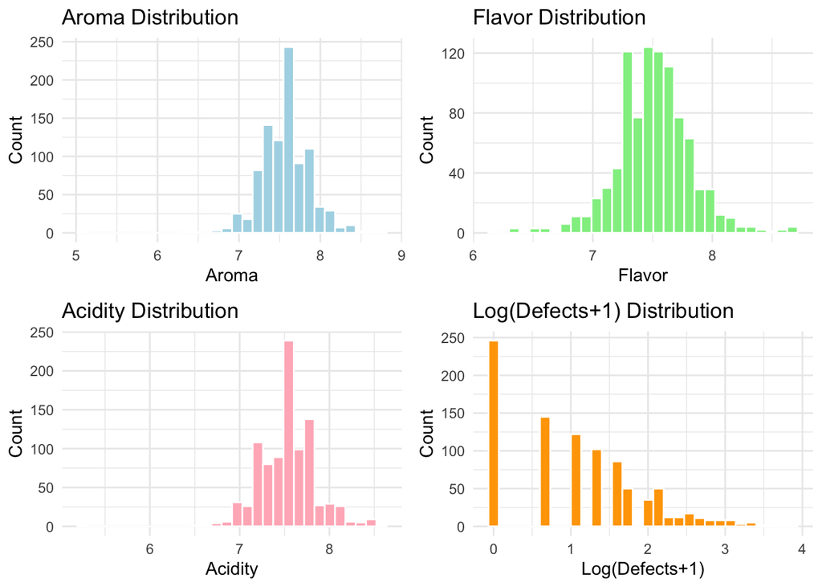

```r
# Plot histograms to visualize the distribution shapes and long tails
p1 <- ggplot(coffee_clean, aes(x = aroma)) +
  geom_histogram(fill="lightblue", color="white", bins=30) +
  theme_minimal() + labs(title="Aroma Distribution", x="Aroma", y="Count")
p2 <- ggplot(coffee_clean, aes(x = flavor)) +
  geom_histogram(fill="lightgreen", color="white", bins=30) +
  theme_minimal() + labs(title="Flavor Distribution", x="Flavor", y="Count")
p3 <- ggplot(coffee_clean, aes(x = acidity)) +
  geom_histogram(fill="lightpink", color="white", bins=30) +
  theme_minimal() + labs(title="Acidity Distribution", x="Acidity", y="Count")
p4 <- ggplot(coffee_clean, aes(x = log_defects)) +
  geom_histogram(fill="orange", color="white", bins=30) +
  theme_minimal() + labs(title="Log(Defects+1) Distribution", x="Log(Defects+1)", y="Count")
# Arrange all four plots in a 2x2 grid for better readability
grid.arrange(p1, p2, p3, p4, ncol=2, nrow=2)
```

The histograms reveal that the sensory attributes (aroma, flavor, and acidity) roughly follow a normal distribution centered around 7.5, with a few natural extreme low scores acting as the left tail. For the defects variable, we applied a log(x+1) transformation to address its severe right-skewness. While the resulting log_defects distribution still has many zero values due to the high frequency of zero-defect batches, the transformation effectively compresses the long tail of outliers, making the data more stable for our modeling.

## Altitude Category Distribution

To ensure the reliability of our subsequent statistical modeling, it is essential to verify that our newly engineered `altitude_category` variable has sufficient observations within each group.

```r
# Calculate the count and percentage for each altitude category
altitude_stats <- coffee_clean %>%
  count(altitude_category) %>%
  mutate(Percentage = round(n / sum(n) * 100, 1))
print(altitude_stats)
```

```
# A tibble: 3 × 3
  altitude_category     n Percentage
  <fct>             <int>      <dbl>
1 Low                 358       38.6
2 Medium              280       30.2
3 High                289       31.2
```

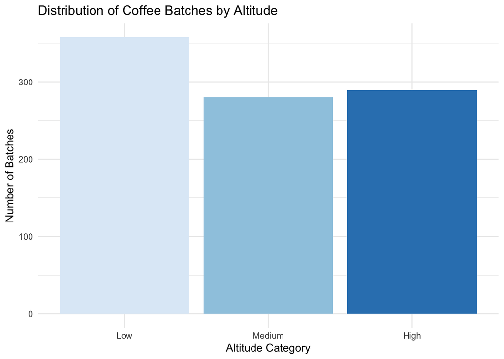

```r
# Visualize the distribution of altitude categories
ggplot(coffee_clean, aes(x = altitude_category, fill = altitude_category)) +
  geom_bar() +
  scale_fill_brewer(palette = "Blues") +
  theme_minimal() +
  labs(title = "Distribution of Coffee Batches by Altitude",
       x = "Altitude Category",
       y = "Number of Batches") +
  theme(legend.position = "none")
```

The distribution table and bar chart show that our altitude_category is well-balanced across all three levels. Low altitude has the most observations (38.6%), followed by Medium (30.2%) and High (31.2%). This balanced distribution is crucial as it ensures our GLM model has enough data in each group to produce statistically significant results, rather than being biased by a single dominant category.

## Correlation & Multicollinearity Check

Before fitting our Generalized Linear Model (GLM), it is vital to check for potential multicollinearity among our continuous predictors. High correlation between independent variables can lead to unstable coefficient estimates. We visualize this using a correlation heatmap .

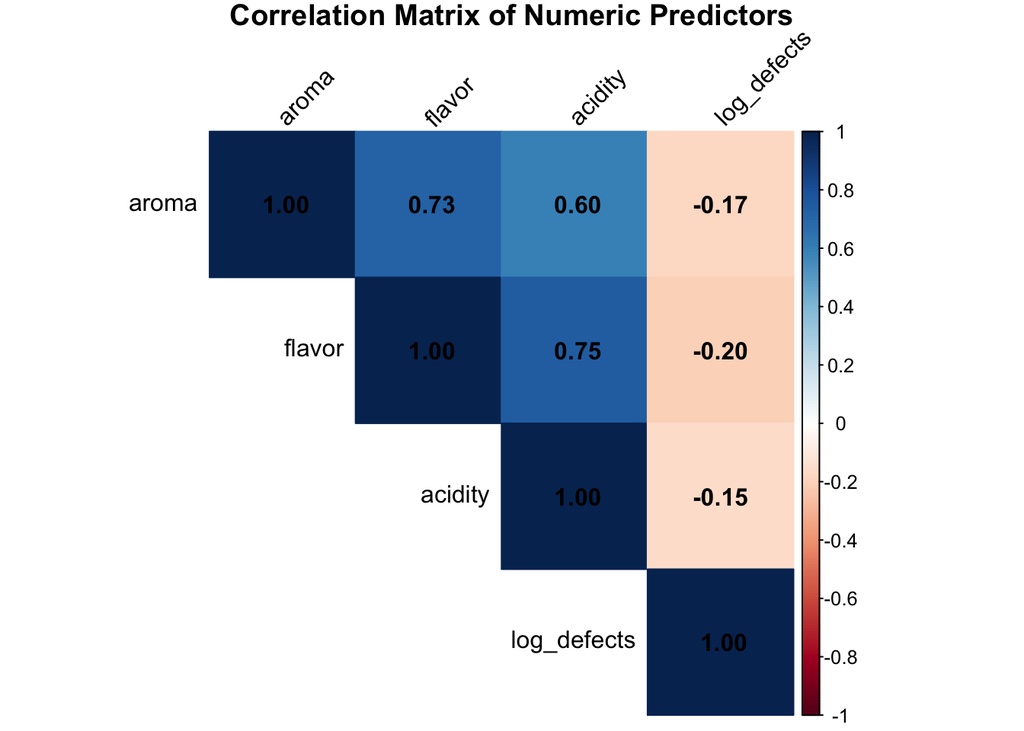

```r
library(corrplot)
# Calculate the correlation matrix for continuous variables
cor_matrix <- coffee_clean %>%
  select(aroma, flavor, acidity, log_defects) %>%
  cor()
# Generate a professional correlation heatmap
corrplot(cor_matrix, method = "color", type = "upper", addCoef.col = "black",
         tl.col = "black", tl.srt = 45,
         title = "Correlation Matrix of Numeric Predictors", mar = c(0,0,1,0))
```

The heatmap indicates strong positive correlations among the sensory attributes, particularly between flavor and acidity ($r \approx 0.75$), and aroma and flavor ($r \approx 0.73$). While expected in coffee cupping (coffees that smell good typically taste good), this high correlation serves as an early warning. It dictates that we must rigorously monitor Variance Inflation Factors (VIF) during the model diagnostic phase to ensure our model remains stable.

## Exploring X vs Y Relationships

Finally, we visually explore how our primary predictors relate to our target variable (Qualityclass) to confirm their predictive potential. We focus on our strongest continuous predictor (Flavor) and our newly engineered categorical predictor (Altitude Category).

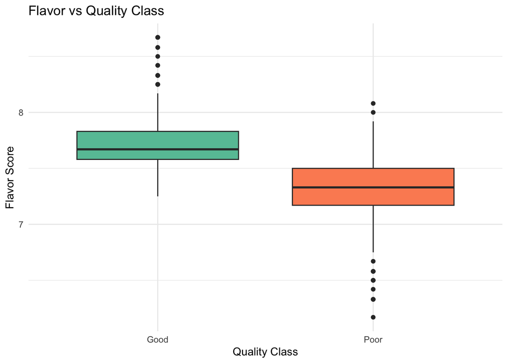

```r
# Plot 1: Flavor distribution across Quality Classes
p_flavor <- ggplot(coffee_clean, aes(x = Qualityclass, y = flavor, fill = Qualityclass)) +
  geom_boxplot() +
  scale_fill_manual(values = c("Good" = "#66c2a5", "Poor" = "#fc8d62")) +
  labs(title = "Flavor vs Quality Class", x = "Quality Class", y = "Flavor Score") +
  theme_minimal() +
  theme(legend.position = "none")
# Plot 2: Quality Class proportion stacked by Altitude Category
p_altitude <- ggplot(coffee_clean, aes(x = altitude_category, fill = Qualityclass)) +
  geom_bar(position = "fill") +
  scale_y_continuous(labels = scales::percent) +
  scale_fill_manual(values = c("Good" = "#66c2a5", "Poor" = "#fc8d62")) +
  labs(title = "Proportion of Good/Poor Coffee by Altitude",
       x = "Altitude Category", y = "Percentage") +
  theme_minimal()
p_flavor
```

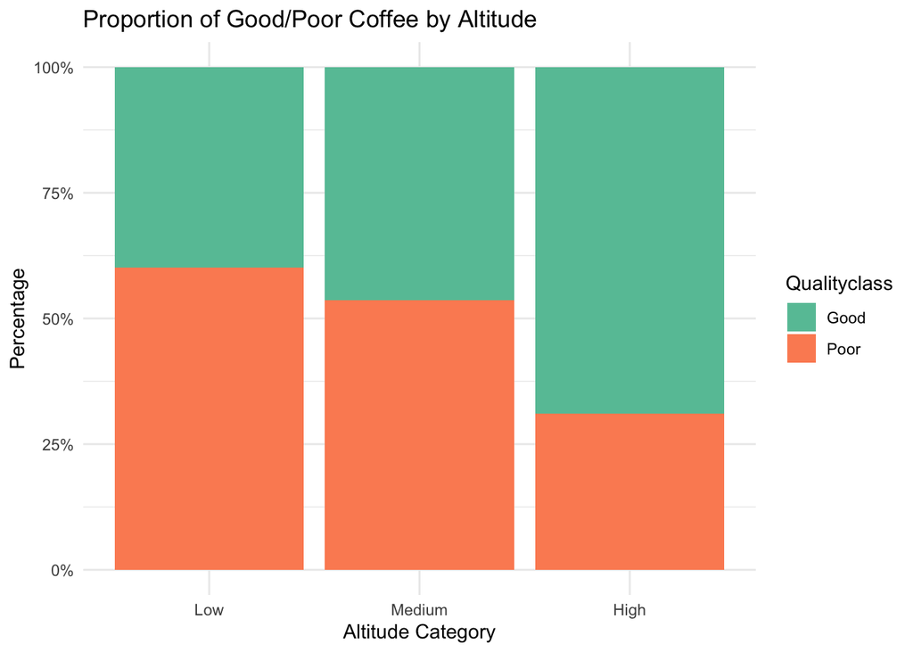

```r
p_altitude
```

# Modelling

## Model Selection: Logistic Regression (GLM)

To investigate the determinants of coffee quality, we fitted a binomial generalized linear model with a logit link, as the response variable Qualityclass is binary.

## Data Partitioning

The cleaned dataset was split into a 70% training set and a 30% hold-out test set using stratified sampling. This ensured that model fitting and final evaluation were conducted on separate data, providing a more credible assessment of out-of-sample performance. For interpretability, Qualityclass was coded with “Poor” as the reference level, and altitude_category was coded with “Low” as the reference level in models where altitude was included.

```r
# Split Training and Test Sets
library(tidyverse)
library(broom)
library(car)
library(pROC)

set.seed(2026)

coffee_clean <- coffee_clean %>%
  mutate(
    Qualityclass = factor(Qualityclass, levels = c("Poor", "Good")),
    altitude_category = factor(altitude_category, levels = c("Low", "Medium", "High"))
  )

# Stratified sampling: 70% for training set, 30% for test set
poor_index <- which(coffee_clean$Qualityclass == "Poor")
good_index <- which(coffee_clean$Qualityclass == "Good")

train_poor <- sample(poor_index, size = floor(0.7 * length(poor_index)))
train_good <- sample(good_index, size = floor(0.7 * length(good_index)))

train_index <- c(train_poor, train_good)

train_data <- coffee_clean[train_index, ]
test_data  <- coffee_clean[-train_index, ]

# Check the class distribution in training and test sets
prop.table(table(train_data$Qualityclass))
```

```
     Poor      Good
0.4907407 0.5092593
```

```r
prop.table(table(test_data$Qualityclass))
```

```
     Poor      Good
0.4910394 0.5089606
```

## Variable Selection

We used a manual backward model simplification strategy to obtain a more parsimonious model. Starting from the full model, log_defects was removed because it was clearly non-significant and its exclusion did not worsen model fit. We then assessed whether altitude_category should be retained by comparing nested models using a likelihood ratio test and AIC. Since altitude did not make a statistically significant contribution and the AIC difference was negligible, the simpler model containing only aroma, flavor, and acidity was selected as the final model.

```r
# Fit Full Model
model_full <- glm(
  Qualityclass ~ aroma + flavor + acidity + log_defects + altitude_category,
  data = train_data,
  family = binomial(link = "logit")
)

summary(model_full)
```

```
Call:
glm(formula = Qualityclass ~ aroma + flavor + acidity + log_defects +
    altitude_category, family = binomial(link = "logit"), data = train_data)

Coefficients:
                          Estimate Std. Error z value Pr(>|z|)
(Intercept)             -1.335e+02  1.158e+01 -11.535  < 2e-16 ***
aroma                    4.682e+00  8.810e-01   5.314 1.07e-07 ***
flavor                   8.002e+00  1.080e+00   7.411 1.25e-13 ***
acidity                  4.976e+00  8.575e-01   5.804 6.49e-09 ***
log_defects             -5.345e-03  1.596e-01  -0.033   0.9733
altitude_categoryMedium  4.591e-02  3.327e-01   0.138   0.8902
altitude_categoryHigh    6.238e-01  3.337e-01   1.869   0.0616 .
---
Signif. codes:  0 '***' 0.001 '**' 0.01 '*' 0.05 '.' 0.1 ' ' 1

(Dispersion parameter for binomial family taken to be 1)

    Null deviance: 898.10  on 647  degrees of freedom
Residual deviance: 351.06  on 641  degrees of freedom
AIC: 365.06

Number of Fisher Scoring iterations: 7
```

```r
# Remove the non-significant log_defects variable
model_reduced1 <- glm(
  Qualityclass ~ aroma + flavor + acidity + altitude_category,
  data = train_data,
  family = binomial(link = "logit")
)

summary(model_reduced1)
```

```
Call:
glm(formula = Qualityclass ~ aroma + flavor + acidity + altitude_category,
    family = binomial(link = "logit"), data = train_data)

Coefficients:
                          Estimate Std. Error z value Pr(>|z|)
(Intercept)             -133.54826   11.57745 -11.535  < 2e-16 ***
aroma                      4.67989    0.87955   5.321 1.03e-07 ***
flavor                     8.00354    1.07888   7.418 1.19e-13 ***
acidity                    4.97608    0.85737   5.804 6.48e-09 ***
altitude_categoryMedium    0.04447    0.32994   0.135   0.8928
altitude_categoryHigh      0.62290    0.33259   1.873   0.0611 .
---
Signif. codes:  0 '***' 0.001 '**' 0.01 '*' 0.05 '.' 0.1 ' ' 1

(Dispersion parameter for binomial family taken to be 1)

    Null deviance: 898.10  on 647  degrees of freedom
Residual deviance: 351.06  on 642  degrees of freedom
AIC: 363.06

Number of Fisher Scoring iterations: 7
```

```r
#compare full model with model_reduced1
anova(model_reduced1, model_full, test = "Chisq")
```

```
Analysis of Deviance Table

Model 1: Qualityclass ~ aroma + flavor + acidity + altitude_category
Model 2: Qualityclass ~ aroma + flavor + acidity + log_defects + altitude_category
  Resid. Df Resid. Dev Df  Deviance Pr(>Chi)
1       642     351.06
2       641     351.06  1 0.0011211   0.9733
```

```r
AIC(model_reduced1, model_full)
```

```
               df      AIC
model_reduced1  6 363.0646
model_full      7 365.0635
```

```r
#check whether altitude_category should be retained as a whole
model_reduced2 <- glm(
  Qualityclass ~ aroma + flavor + acidity,
  data = train_data,
  family = binomial(link = "logit")
)

summary(model_reduced2)
```

```
Call:
glm(formula = Qualityclass ~ aroma + flavor + acidity, family = binomial(link = "logit"),
    data = train_data)

Coefficients:
             Estimate Std. Error z value Pr(>|z|)
(Intercept) -133.8969    11.4846 -11.659  < 2e-16 ***
aroma          4.9317     0.8605   5.731 9.96e-09 ***
flavor         7.7664     1.0567   7.349 1.99e-13 ***
acidity        5.0336     0.8512   5.914 3.34e-09 ***
---
Signif. codes:  0 '***' 0.001 '**' 0.01 '*' 0.05 '.' 0.1 ' ' 1

(Dispersion parameter for binomial family taken to be 1)

    Null deviance: 898.10  on 647  degrees of freedom
Residual deviance: 355.28  on 644  degrees of freedom
AIC: 363.28

Number of Fisher Scoring iterations: 7
```

```r
# compare model_reduced1 with model_reduced2
anova(model_reduced2, model_reduced1, test = "Chisq")
```

```
Analysis of Deviance Table

Model 1: Qualityclass ~ aroma + flavor + acidity
Model 2: Qualityclass ~ aroma + flavor + acidity + altitude_category
  Resid. Df Resid. Dev Df Deviance Pr(>Chi)
1       644     355.28
2       642     351.06  2   4.2118   0.1217
```

```r
AIC(model_reduced2, model_reduced1)
```

```
               df      AIC
model_reduced2  4 363.2764
model_reduced1  6 363.0646
```

## Multicollinearity Check

Because the sensory predictors were moderately correlated, multicollinearity was assessed using the Variance Inflation Factor (VIF). This diagnostic was included to ensure that overlap among predictors did not materially distort the coefficient estimates.

```r
library(car)

vif(model_reduced2)
```

[output not shown]

## Model Validation (ROC and AUC)

The final model was evaluated on the hold-out test set using ROC analysis. The resulting AUC of 0.934 indicates excellent discriminatory ability, suggesting that the model performs very well in separating “Good” from “Poor” coffee batches on unseen data.

```r
# Predict on test set using the final model
test_probs_final <- predict(model_reduced2, newdata = test_data, type = "response")

# ROC and AUC (on test set)
test_roc_final <- roc(
  response = test_data$Qualityclass,
  predictor = test_probs_final,
  levels = c("Poor", "Good"),
  direction = "<"
)

auc(test_roc_final)
```

```
Area under the curve: 0.9342
```

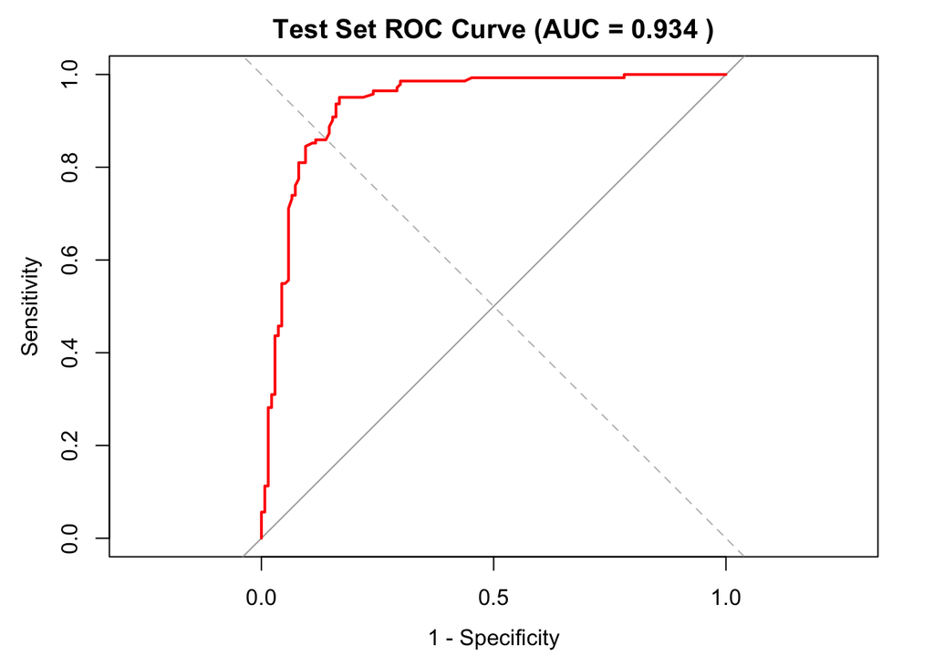

```r
# Plot the ROC curve
plot(
  test_roc_final,
  col = "red",
  lwd = 2,
  legacy.axes = TRUE,
  main = paste("Test Set ROC Curve (AUC =", round(auc(test_roc_final), 3), ")")
)
abline(a = 0, b = 1, lty = 2, col = "gray")
```

```r
round(auc(test_roc_final), 3)
```

```
[1] 0.934
```

## Odds Ratio (OR) table

While the ROC curve and AUC evaluate the predictive performance of the final model on unseen data, they do not show how individual predictors are associated with coffee quality classification. To address this, we report the Odds Ratios (ORs) for the final logistic regression model. In this context, each OR represents the multiplicative change in the odds of being classified as “Good” for a one-unit increase in the corresponding sensory score, conditional on the other predictors being held constant. The OR table therefore complements the ROC analysis by providing an interpretable summary of the contribution of aroma, flavor, and acidity.

```r
# Extract non-intercept terms
coef_est <- coef(model_reduced2)[-1]
or_est <- exp(coef_est)
ci_or <- exp(confint(model_reduced2))[-1, ]
p_vals <- summary(model_reduced2)$coefficients[-1, 4]

# Odds Ratio (OR) table
or_table <- data.frame(
  Variable = names(coef_est),
  Coefficient = round(coef_est, 3),
  OR = round(or_est, 3),
  CI_Lower = round(ci_or[, 1], 3),
  CI_Upper = round(ci_or[, 2], 3),
  p_value = round(p_vals, 4)
)

or_table
```

```
        Variable Coefficient       OR CI_Lower  CI_Upper p_value
aroma      aroma       4.932  138.615   26.995   793.433       0
flavor    flavor       7.766 2360.014  326.417 20759.769       0
acidity  acidity       5.034  153.490   30.326   860.891       0
```

# Conclusion

The results of this analysis suggest that the main factors influencing coffee quality classification in this dataset are sensory characteristics rather than production-related variables. In the final logistic regression model, aroma, flavor, and acidity were all positively associated with the odds of being classified as “Good”, with flavor showing the strongest effect among the retained predictors.

Although altitude showed some association in the exploratory analysis, it did not provide substantial additional explanatory value once the sensory variables were included in the model. Similarly, the defect measure did not make a meaningful contribution after controlling for sensory scores. This suggests that final coffee quality classification is more closely related to overall cupping performance than to production conditions or minor physical defects alone.

The final model also performed very well on the hold-out test set, achieving an AUC of 0.934. This indicates excellent ability to distinguish between “Good” and “Poor” coffee samples in unseen data. Overall, the findings suggest that sensory attributes are the most important predictors of coffee quality classification in this dataset, while altitude and defect measures play a more limited role once cupping characteristics are taken into account.